# Gravity falls

Michalina Pol

05.05.2018

[figure not shown]

Gravity Falls

# Gravity Falls

Amerykański serial animowany, wchodzący w kanon Disney Channel Original Series. Został on stworzony przez Alexa Hirscha. Swoją premierę miał 15 czerwca 2012 w USA na kanale Disney Channel, a w Polsce 20 września 2012, również na Disney Channel.

### Fabuła

Plany rodzeństwa Dippera i Mabel Pines zostają zrujnowane, gdy rodzice wysyłają ich do domku wujka Stana w Wodogrzmotach Małych (Gravity Falls) w stanie Oregon, który prowadzi najdziwniejsze na świecie muzeum The Mystery Shack (Tajemnicza Chata), będące w rzeczywistości turystyczną pułapką. Wkrótce Dipper i Mabel odkrywają jak tajemnicza jest miejscowość ich zwariowanego wujka i próbują zrobić wszystko, by nauczyć się żyć w Wodogrzmotach.

### Reżyserowie:

- John Aoshima
- Aaron Springer
- Joe Pitt

### Bohateriowie

1. *Mason “Dipper” Pines* - Brat bliźniak Mabel, bystry, pomysłowy i ciekawy świata realista. Ma 12 lat i interesuje się rozwiązywaniem zagadek.
2. *Mabel Pines* - Pełna energii i optymizmu, choć nieco szalona siostra bliźniaczka Dippera. Potrafi znaleźć coś pozytywnego w każdej sytuacji, a robi to z szerokim, choć niezbyt inteligentnym uśmiechem, który strasznie denerwuje jej brata. Mabel interesuje się tym, czym inne dziewczyny w jej wieku, między innymi podrywaniem chłopców, słodyczami i muzyką.
3. *Stanley “Stanek” Pines* - wujek Dippera i Mabel, właściciel Tajemniczej Chaty i jedna z najbardziej tajemniczych postaci serii. Ma dwóch braci - bliźniaczego Stanforda i młodszego Shermiego, który jest dziadkiem Dippera i Mabel. Wujek Stanek jest kanciarzem i oszustem, którego celem jest zdobywanie jak największej ilości pieniędzy na turystach przychodzących do jego pseudomuzeum oglądać tajemnicze, choć tak naprawdę fałszywe eksponaty.
4. **Jesus “Soos” Ramirez* - uroczy, teoretycznie dorosły, ale niezbyt dojrzały 22-letni chłopak pochodzenia hiszpańskiego. Od 12 roku życia za darmo pracuje w Tajemniczej Chacie. Jest najlepszym przyjacielem Dippera, zaś Stanka uważa za namiastkę ojca.
5. *Wendy Corduroy* - obiekt westchnień Dippera, rudowłosa 15-letnia dziewczyna pracująca w Tajemniczej Chacie. Pochodzi z rodziny drwali i umie dobrze posługiwać się siekierą.

| Seria | Ilość odcinków | Premiera serii | Finał serii |
| --- | --- | --- | --- |
| 1 | 20 | 15.06.2012 | 2.08.2013 |
| 2 | 21 | 1.08.2014 | 15.02.2016 |

[Tu możesz obejrzeć](https://www.netflix.com/watch/80017586?trackId=13752289&tctx=0%2C2%2Cad38671824f090fe5446f75004a7503187ec7daf%3A5c20880d2b90565051ac4c04d12ecbd04c42d76f%2C%2C)

# Pozostałe (nie w temacie)

> ```
> ggplot(data = mpg) +
> geom_histogram(mapping = aes(displ), bins = 15) +
> labs(title = "Pojemności silnika", x = "Pojemność", y = "Liczba samochodów")
> ```

# Rstudio

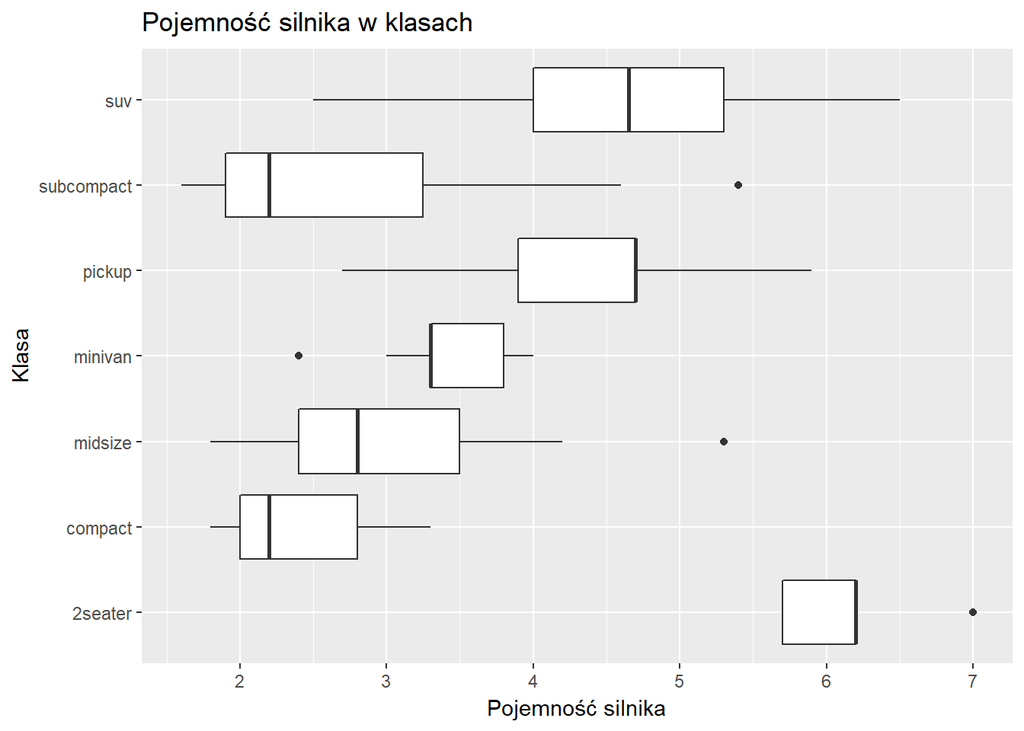

```r
library(ggplot2)
ggplot(data = mpg, aes(x = class, y = displ)) +
  geom_boxplot() +
  coord_flip() +
  labs(title = "Pojemność silnika w klasach", x = "Klasa", y = "Pojemność silnika")
```

```r
library(tidyverse)
diamonds %>% filter(cut == "Good")
```

| carat | cut | color | clarity | depth | table | price | x | y | z |
| --- | --- | --- | --- | --- | --- | --- | --- | --- | --- |
| 0.23 | Good | E | VS1 | 56.9 | 65.0 | 327 | 4.05 | 4.07 | 2.31 |
| 0.31 | Good | J | SI2 | 63.3 | 58.0 | 335 | 4.34 | 4.35 | 2.75 |
| 0.30 | Good | J | SI1 | 64.0 | 55.0 | 339 | 4.25 | 4.28 | 2.73 |
| 0.30 | Good | J | SI1 | 63.4 | 54.0 | 351 | 4.23 | 4.29 | 2.70 |
| 0.30 | Good | J | SI1 | 63.8 | 56.0 | 351 | 4.23 | 4.26 | 2.71 |
| 0.30 | Good | I | SI2 | 63.3 | 56.0 | 351 | 4.26 | 4.30 | 2.71 |
| 0.23 | Good | F | VS1 | 58.2 | 59.0 | 402 | 4.06 | 4.08 | 2.37 |
| 0.23 | Good | E | VS1 | 64.1 | 59.0 | 402 | 3.83 | 3.85 | 2.46 |
| 0.31 | Good | H | SI1 | 64.0 | 54.0 | 402 | 4.29 | 4.31 | 2.75 |
| 0.26 | Good | D | VS2 | 65.2 | 56.0 | 403 | 3.99 | 4.02 | 2.61 |

[output cut: 4896 more lines]

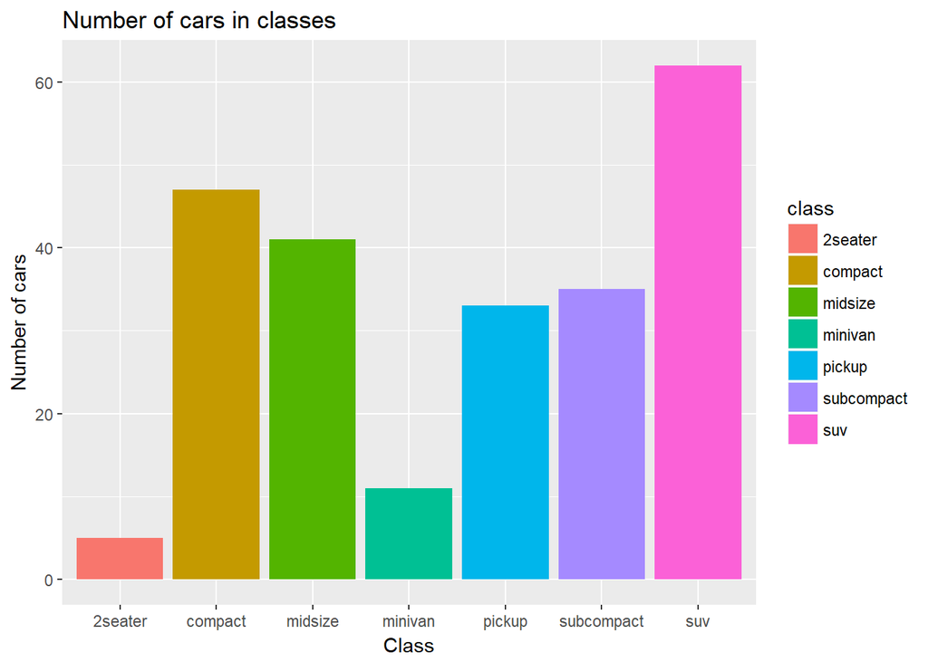

```r
library(tidyverse)
ggplot(data = mpg) +
  geom_bar(mapping = aes(x = class, fill = class)) +
  labs(title = "Number of cars in classes", x = "Class", y = "Number of cars")
```